# Automated model building/testing

Data is a combination of patterns (trends) and noise(variance/residuals) *Point of statistical modelling is to find the pattern*

```r
library(CodeClanData)
library(tidyverse)
```

| gender | name | surname | job_area | salary | age | retired | location | savings |
| --- | --- | --- | --- | --- | --- | --- | --- | --- |
| Female | Jools | Williamson | Legal | 19000 | 41 | No | Shetland | 33451 |
| Male | Jimmy | Laurenceso | Product Management | 21000 | 78 | Yes | Edinburgh | 27308 |
| Male | Freddy | Irvine | Human Resources | 18000 | 31 | No | Inverness | 37337 |
| Male | Jimmy | Tait | Sales | 19000 | 90 | Yes | Edinburgh | 15699 |
| Female | India | Sinclair | Product Management | 23000 | 19 | No | Shetland | 46726 |
| Male | Jimmy | Laurenceso | Human Resources | 25000 | 20 | No | Aberdeen | 38405 |
| Female | Helena | Jamieson | Training | 11000 | 32 | No | Glasgow | 49070 |
| Female | Helena | Galdie | Legal | 18000 | 60 | No | Inverness | 40517 |
| Male | Charles | Nicolson | Product Management | 23000 | 69 | Yes | Aberdeen | 16894 |
| Male | Gord | Fraser | Sales | 24000 | 39 | No | Orkney | 22508 |

[output cut: 990 more lines]

Overfitting model

Well fitted model

Under fitted model

# Parsimonious(simple) measures of goodness-of-fit.

- Adjusted R-squared - larger value is better
- AIC - smaller values are better
- BIC - smaller values are better (this tends to be the most parsimonious)

measure = goodness of fit +/- parameter penalty

Analysis of model_overfit below:

```r
summary(model_overfit)
```

```
Call:
lm(formula = savings ~ ., data = savings)

Residuals:
   Min     1Q Median     3Q    Max
-27670  -6563   -188   6167  35227

Coefficients: (1 not defined because of singularities)
                             Estimate Std. Error t value Pr(>|t|)
(Intercept)                 2.372e+04  2.442e+03   9.713  < 2e-16 ***
genderMale                  3.371e+02  1.708e+03   0.197  0.84358
nameAngus                  -1.345e+03  1.747e+03  -0.770  0.44162
nameBert                   -6.908e+02  1.696e+03  -0.407  0.68381
nameBonnie                  1.601e+03  1.686e+03   0.950  0.34247
nameCara                    1.247e+03  1.741e+03   0.716  0.47402
nameCharles                 4.416e+01  1.711e+03   0.026  0.97941
nameDonald                  2.381e+03  1.910e+03   1.246  0.21291
nameDora                   -1.814e+03  1.742e+03  -1.042  0.29785
nameEd                      2.710e+03  1.780e+03   1.523  0.12812
nameEmmy                    2.105e+03  1.699e+03   1.239  0.21547
nameFlorence                1.466e+03  1.713e+03   0.856  0.39227
nameFreddy                  2.080e+02  1.695e+03   0.123  0.90239
nameGilly                  -7.143e+02  1.802e+03  -0.396  0.69191
nameGord                   -6.295e+02  1.821e+03  -0.346  0.72965
nameHarry                   2.188e+02  1.785e+03   0.123  0.90249
nameHelena                  1.284e+03  1.753e+03   0.732  0.46416
nameIndia                   2.854e+03  1.785e+03   1.599  0.11020
nameIvan                    1.210e+03  1.893e+03   0.639  0.52286
nameJimmy                          NA         NA      NA       NA
nameJools                  -6.668e+02  1.699e+03  -0.392  0.69484
surnameFraser              -3.660e+03  1.875e+03  -1.952  0.05122 .
surnameGaldie              -1.706e+03  1.826e+03  -0.934  0.35037
surnameHalcrow             -1.636e+03  1.728e+03  -0.947  0.34380
surnameHenderson           -2.878e+03  1.728e+03  -1.665  0.09614 .
surnameIrvine              -1.554e+03  1.698e+03  -0.915  0.36043
surnameJamieson            -4.087e+03  1.795e+03  -2.276  0.02301 *
surnameJohnson             -5.021e+03  1.806e+03  -2.780  0.00552 **
surnameLaurenceso          -3.387e+03  1.773e+03  -1.910  0.05637 .
surnameLeask               -1.332e+03  1.727e+03  -0.771  0.44070
surnameManson              -4.294e+03  1.807e+03  -2.376  0.01767 *
```

[output cut: 14 more lines]

```
age                         1.579e+02  2.397e+01   6.590 6.68e-11 ***
retiredYes                 -1.956e+04  1.070e+03 -18.288  < 2e-16 ***
locationEdinburgh           1.434e+03  1.127e+03   1.273  0.20339
locationGlasgow             2.753e+03  1.183e+03   2.327  0.02016 *
locationInverness           8.503e+02  1.195e+03   0.711  0.47695
locationOrkney              9.116e+02  1.122e+03   0.813  0.41656
locationShetland            2.284e+03  1.152e+03   1.982  0.04770 *
locationStirling            1.559e+03  1.136e+03   1.372  0.17018
locationWestern Isles       1.290e+03  1.121e+03   1.151  0.24990
---
Signif. codes:  0 ‘***’ 0.001 ‘**’ 0.01 ‘*’ 0.05 ‘.’ 0.1 ‘ ’ 1

Residual standard error: 9634 on 1147 degrees of freedom
Multiple R-squared:  0.3715,    Adjusted R-squared:  0.343
F-statistic: 13.04 on 52 and 1147 DF,  p-value: < 2.2e-16
```

```r
summary(model_overfit)$adj.r.squared
```

```
[1] 0.3429625
```

```r
AIC(model_overfit)
```

```
[1] 25474.46
```

```r
BIC(model_overfit)
```

```
[1] 25749.33
```

```r
library(broom)
```

| r.squared | adj.r.squared | sigma | statistic | p.value | df | logLik | AIC | BIC | deviance | df.residual |
| --- | --- | --- | --- | --- | --- | --- | --- | --- | --- | --- |
| 0.3714579 | 0.3429625 | 9633.547 | 13.03573 | 4.373571e-83 | 53 | -12683.23 | 25474.46 | 25749.33 | 106447586521 | 1147 |

Analysis of model_wellfit below:

```r
summary(model_wellfit)
```

```
Call:
lm(formula = savings ~ salary + age + retired, data = savings)

Residuals:
   Min     1Q Median     3Q    Max
-28659  -6968    -59   6410  39736

Coefficients:
              Estimate Std. Error t value Pr(>|t|)
(Intercept)  2.227e+04  1.604e+03  13.882  < 2e-16 ***
salary       4.854e-01  6.207e-02   7.820 1.15e-14 ***
age          1.600e+02  2.351e+01   6.806 1.59e-11 ***
retiredYes  -1.959e+04  1.052e+03 -18.612  < 2e-16 ***
---
Signif. codes:  0 ‘***’ 0.001 ‘**’ 0.01 ‘*’ 0.05 ‘.’ 0.1 ‘ ’ 1

Residual standard error: 9665 on 1196 degrees of freedom
Multiple R-squared:  0.3403,    Adjusted R-squared:  0.3387
F-statistic: 205.7 on 3 and 1196 DF,  p-value: < 2.2e-16
```

```r
summary(model_wellfit)$adj.r.squared
```

```
[1] 0.3386625
```

```r
AIC(model_wellfit)
```

```
[1] 25434.49
```

```r
BIC(model_wellfit)
```

```
[1] 25459.94
```

| r.squared | adj.r.squared | sigma | statistic | p.value | df | logLik | AIC | BIC | deviance | df.residual |
| --- | --- | --- | --- | --- | --- | --- | --- | --- | --- | --- |
| 0.3403172 | 0.3386625 | 9665.019 | 205.6642 | 1.479567e-107 | 4 | -12712.24 | 25434.49 | 25459.94 | 111721457932 | 1196 |

Analysis of model_underfit below:

```r
summary(model_underfit)
```

```
Call:
lm(formula = savings ~ salary, data = savings)

Residuals:
   Min     1Q Median     3Q    Max
-38662  -7640     53   8231  35808

Coefficients:
             Estimate Std. Error t value Pr(>|t|)
(Intercept) 2.477e+04  1.525e+03  16.243  < 2e-16 ***
salary      4.846e-01  7.506e-02   6.456 1.56e-10 ***
---
Signif. codes:  0 ‘***’ 0.001 ‘**’ 0.01 ‘*’ 0.05 ‘.’ 0.1 ‘ ’ 1

Residual standard error: 11690 on 1198 degrees of freedom
Multiple R-squared:  0.03362,   Adjusted R-squared:  0.03281
F-statistic: 41.68 on 1 and 1198 DF,  p-value: 1.56e-10
```

```r
summary(model_underfit)$adj.r.squared
```

```
[1] 0.0328133
```

```r
AIC(model_underfit)
```

```
[1] 25888.65
```

```r
BIC(model_underfit)
```

```
[1] 25903.92
```

| r.squared | adj.r.squared | sigma | statistic | p.value | df | logLik | AIC | BIC | deviance | df.residual |
| --- | --- | --- | --- | --- | --- | --- | --- | --- | --- | --- |
| 0.03361997 | 0.0328133 | 11688.16 | 41.67793 | 1.55991e-10 | 2 | -12941.32 | 25888.65 | 25903.92 | 163662583678 | 1198 |

### Test & Train

- dummy excersise

```r
#find the size of data
n_data <- nrow(students_big) #912 rows
test_index <- sample(1:n_data, size = n_data*0.1)

test <- slice(students_big, test_index)
train <- slice(students_big, -test_index)
```

train data

```r
model <- lm(height ~ arm_span, data = train)
```

predict test data

check the difference

```r
median(abs(predictions - test$height))
```

```
[1] 5.665161
```

- savings data test & train excersize

** Fitting model & testing

```r
#overfitted
over_n_data <- nrow(savings) #1200
over_test_index <- sample(1:over_n_data, size = over_n_data*0.1)

test_over <- slice(savings, over_test_index)
train_over <- slice(savings, -over_test_index)
#underfitted
under_n_data <- nrow(savings)
under_test_index <- sample(1:under_n_data, size = under_n_data*0.1)

test_under <- slice(savings, under_test_index)
train_under <- slice(savings, -under_test_index)
#wellfitted
well_n_data <- nrow(savings)
well_test_index <- sample(1:well_n_data, size = well_n_data*0.1)

test_well <- slice(savings, well_test_index)
train_well <- slice(savings, -well_test_index)
```

train

```r
model_over <- lm(savings ~ ., data = train_over)
model_under <- lm(savings ~ salary, data = train_under)
model_well <- lm(savings ~ salary + age + retired, data = train_well)
```

predict

```r
predict_over <- predict(model_over, data = test_over)
predict_under <- predict(model_under, data = test_under)
predict_well <- predict(model_well, data = test_well)
```

check difference

```r
#overfitted
median(abs(predict_over - test_over$savings))
```

```
[1] 9248.739
```

```r
#underfitted
median(abs(predict_under - test_under$savings))
```

```
[1] 8276.791
```

```r
#wellfitted
median(abs(predict_well - test_well$savings))
```

```
[1] 8057.569
```

# K-fold cross validation

(harnesses both pasimonious and test/train benefits)

usually select 10-folks.

disadvantage: slow to run

```r
library(caret)

#crossvalidation 10 fold
cv_10_fold <- trainControl(method = "cv",
                           number = 10,
                           savePredictions = TRUE)

model<- train(savings ~ ., data = savings, trControl = cv_10_fold, method = "lm")
```

[output not shown]

```r
#all models are contained in model object
```

| pred | obs | rowIndex | intercept | Resample |
| --- | --- | --- | --- | --- |
| 33714.50 | 49070 | 7 | TRUE | Fold01 |
| 27119.47 | 17513 | 32 | TRUE | Fold01 |
| 41970.06 | 45440 | 40 | TRUE | Fold01 |
| 40197.82 | 17570 | 60 | TRUE | Fold01 |
| 42100.94 | 45193 | 61 | TRUE | Fold01 |
| 28706.89 | 24925 | 85 | TRUE | Fold01 |
| 34429.91 | 39948 | 98 | TRUE | Fold01 |
| 45905.38 | 49067 | 102 | TRUE | Fold01 |
| 28758.19 | 7665 | 113 | TRUE | Fold01 |
| 39491.25 | 29434 | 121 | TRUE | Fold01 |

[output cut: 990 more lines]

| RMSE | Rsquared | MAE | Resample |
| --- | --- | --- | --- |
| 9387.547 | 0.2896982 | 7123.146 | Fold01 |
| 9493.549 | 0.3466605 | 7567.834 | Fold02 |
| 9617.350 | 0.3203533 | 7511.042 | Fold03 |
| 9848.940 | 0.2596526 | 8093.206 | Fold04 |
| 9948.150 | 0.2694253 | 7842.904 | Fold05 |
| 10366.210 | 0.3593026 | 8285.355 | Fold06 |
| 10324.449 | 0.3286179 | 8026.617 | Fold07 |
| 10304.898 | 0.3151677 | 7872.092 | Fold08 |
| 9257.438 | 0.4099992 | 7565.116 | Fold09 |
| 9688.674 | 0.3140391 | 7862.779 | Fold10 |

```r
mean(model$resample$RMSE)
```

```
[1] 9823.72
```

```r
mean(model$resample$Rsquared)
```

```
[1] 0.3212916
```

```r
well_fitted_10_fold <- trainControl(method = "cv",
                           number = 10,
                           savePredictions = TRUE)

well_fitted_10_fold_model<- train(savings ~ salary + age + retired, data = savings, trControl = well_fitted_10_fold, method = "lm")
```

```r
mean(well_fitted_10_fold_model$resample$RMSE)
```

```
[1] 9668.512
```

```r
mean(well_fitted_10_fold_model$resample$Rsquared)
```

```
[1] 0.337834
```

[figure not shown]

### Forward selection - incrementally increasing complexity of a model

### Backward selection - start with overfitted model, trying to find what features decrease r-square the lest.

#Best subset selection - theoretically the best way to do it. drawback: slow

available packages: leaps & GLMmulti

| age | sex | bmi | children | smoker | region | charges |
| --- | --- | --- | --- | --- | --- | --- |
| 19 | female | 27.900 | 0 | yes | southwest | 16884.924 |
| 18 | male | 33.770 | 1 | no | southeast | 1725.552 |
| 28 | male | 33.000 | 3 | no | southeast | 4449.462 |
| 33 | male | 22.705 | 0 | no | northwest | 21984.471 |
| 32 | male | 28.880 | 0 | no | northwest | 3866.855 |
| 31 | female | 25.740 | 0 | no | southeast | 3756.622 |
| 46 | female | 33.440 | 1 | no | southeast | 8240.590 |
| 37 | female | 27.740 | 3 | no | northwest | 7281.506 |
| 37 | male | 29.830 | 2 | no | northeast | 6406.411 |
| 60 | female | 25.840 | 0 | no | northwest | 28923.137 |

[output cut: 990 more lines]

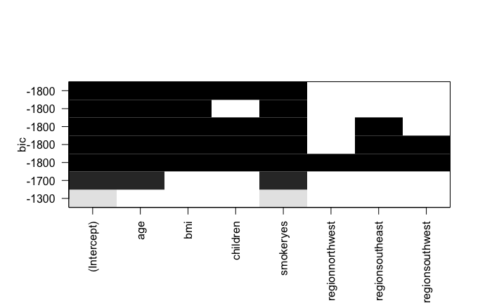

```r
#need to establish how many variables and define it in nvmax
reg_subsets_forward <- regsubsets(charges ~ . -sex, data = insurance, nvmax = 8, method = "forward" )

plot(reg_subsets_forward, scale = "bic") #adjr2 = adjusted r-sq value
```

```r
summary(reg_subsets_forward)
```

```
Subset selection object
Call: regsubsets.formula(charges ~ . - sex, data = insurance, nvmax = 8,
    method = "forward")
7 Variables  (and intercept)
                Forced in Forced out
age                 FALSE      FALSE
bmi                 FALSE      FALSE
children            FALSE      FALSE
smokeryes           FALSE      FALSE
regionnorthwest     FALSE      FALSE
regionsoutheast     FALSE      FALSE
regionsouthwest     FALSE      FALSE
1 subsets of each size up to 7
Selection Algorithm: forward
         age bmi children smokeryes regionnorthwest regionsoutheast
1  ( 1 ) " " " " " "      "*"       " "             " "
2  ( 1 ) "*" " " " "      "*"       " "             " "
3  ( 1 ) "*" "*" " "      "*"       " "             " "
4  ( 1 ) "*" "*" "*"      "*"       " "             " "
5  ( 1 ) "*" "*" "*"      "*"       " "             "*"
6  ( 1 ) "*" "*" "*"      "*"       " "             "*"
7  ( 1 ) "*" "*" "*"      "*"       "*"             "*"
         regionsouthwest
1  ( 1 ) " "
2  ( 1 ) " "
3  ( 1 ) " "
4  ( 1 ) " "
5  ( 1 ) " "
6  ( 1 ) "*"
7  ( 1 ) "*"
```

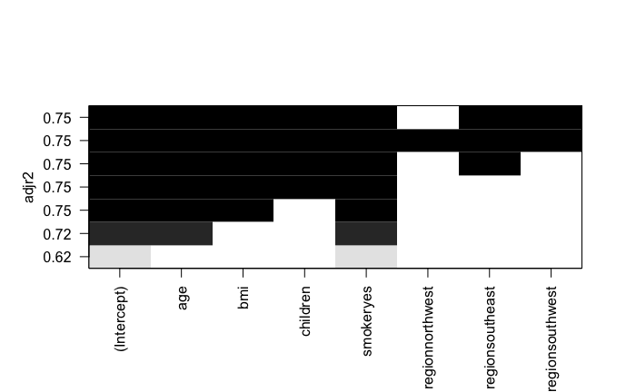

```r
reg_subsets_backward <- regsubsets(charges ~ . -sex, data = insurance,nvmax = 8, method = "backward")

plot(reg_subsets_backward, scale = "adjr2")
```

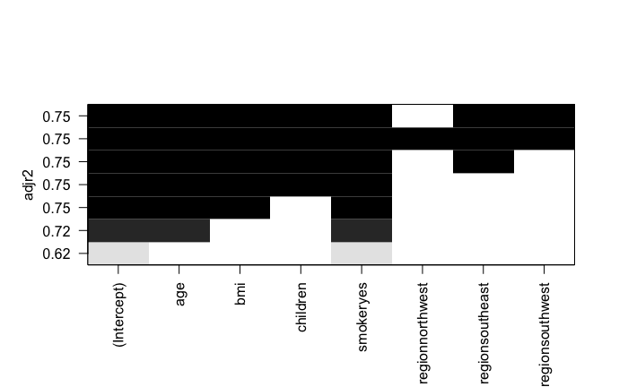

```r
reg_subsets_exhaustive<-regsubsets(charges ~ . -sex, data = insurance,nvmax = 8, method = "exhaustive")
plot(reg_subsets_exhaustive, scale = "adjr2")
```

## Deciding between models:

```r
model_with_region <- lm(charges ~ age, bmi, children, smoker, region, data = insurance)
```

```
Error in model.frame.default(formula = charges ~ age, data = insurance,  :
  object 'smoker' not found
```

# How to decide between models????

1. Parsimonious measure of googness of fit
- AIC
- BIC
- Adj - R-sq (higher value better)
2. Test/Train
3. K-fold cross validation
4. ANOVA p-values (under 0.05/0.01) & Residual Errors (low)
5. Diagnostic plots